# Dimensionality reduction techniques

This week I learned about dimensionality reduction techniques.

## 1. Meet the human data

First I read in data about human development. The data consists of several indicators that are thought to be important for a measure called ‘human development index’. This index is thought to measure the development of a country from a human perspective, so that a country’s development would not be measured only on economical terms.

```r
human<-read.csv("C:/Users/Sirke Piirainen/Documents/GitHub/IODS-project/data/human2.csv",header = T, row.names=1)
str(human)
```

```
## 'data.frame':    155 obs. of  8 variables:
##  $ RAT.EDU: num  0.198 0.931 0.861 0.977 0.989 ...
##  $ RAT.LAB: num  0.199 0.685 0.211 0.633 0.747 ...
##  $ EYE    : num  9.3 11.8 14 17.9 12.3 20.2 15.7 11.9 12.6 14.4 ...
##  $ LEB    : num  60.4 77.8 74.8 76.3 74.7 82.4 81.4 70.8 75.4 76.6 ...
##  $ GNI    : int  1885 9943 13054 22050 8124 42261 43869 16428 21336 38599 ...
##  $ MMR    : int  400 21 89 69 29 6 4 26 37 22 ...
##  $ ABR    : num  86.8 15.3 10 54.4 27.1 12.1 4.1 40 28.5 13.8 ...
##  $ PARL   : num  27.6 20.7 25.7 36.8 10.7 30.5 30.3 15.6 16.7 15 ...
```

The data consist of 155 observations of 8 variables. Each observation (row) represents a country.

Variables explained:

MMR=maternal mortality ratio

ABR=adolescent birth rate

PARL=Percentange of female representatives in parliament

RAT.EDU=ratio of females to males with at least secondary education

RAT.LAB=ratio of females to males in the labour force

EYE=expected years of education

GNI= gross national income

LEB=life expectancy at birth

All the variables are numerical and mostly continuous.

```r
summary(human)
```

```
##     RAT.EDU          RAT.LAB            EYE             LEB
##  Min.   :0.1717   Min.   :0.1857   Min.   : 5.40   Min.   :49.00
##  1st Qu.:0.7264   1st Qu.:0.5984   1st Qu.:11.25   1st Qu.:66.30
##  Median :0.9375   Median :0.7535   Median :13.50   Median :74.20
##  Mean   :0.8529   Mean   :0.7074   Mean   :13.18   Mean   :71.65
##  3rd Qu.:0.9968   3rd Qu.:0.8535   3rd Qu.:15.20   3rd Qu.:77.25
##  Max.   :1.4967   Max.   :1.0380   Max.   :20.20   Max.   :83.50
##       GNI              MMR              ABR              PARL
##  Min.   :   581   Min.   :   1.0   Min.   :  0.60   Min.   : 0.00
##  1st Qu.:  4198   1st Qu.:  11.5   1st Qu.: 12.65   1st Qu.:12.40
##  Median : 12040   Median :  49.0   Median : 33.60   Median :19.30
##  Mean   : 17628   Mean   : 149.1   Mean   : 47.16   Mean   :20.91
##  3rd Qu.: 24512   3rd Qu.: 190.0   3rd Qu.: 71.95   3rd Qu.:27.95
##  Max.   :123124   Max.   :1100.0   Max.   :204.80   Max.   :57.50
```

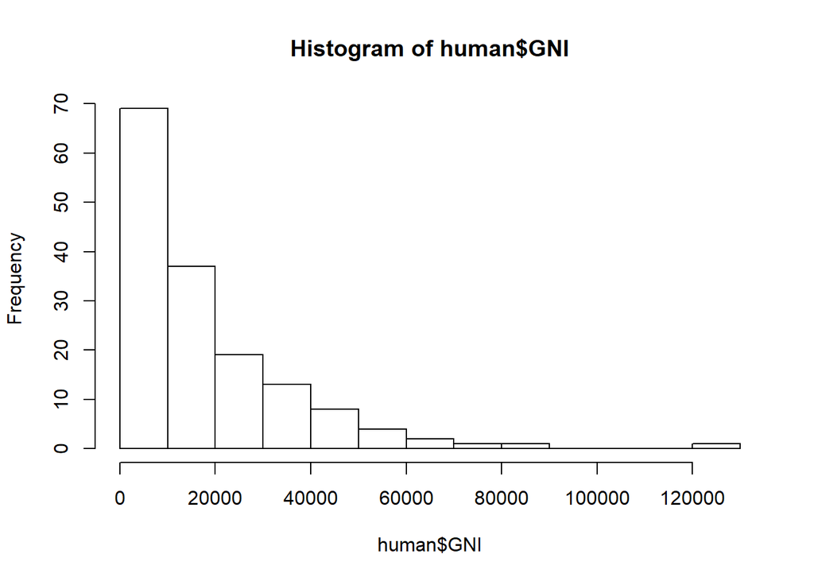

```r
hist(human$GNI)
```

Some of the variables (for example GNI) have very wide distributions and are not normally distributed.

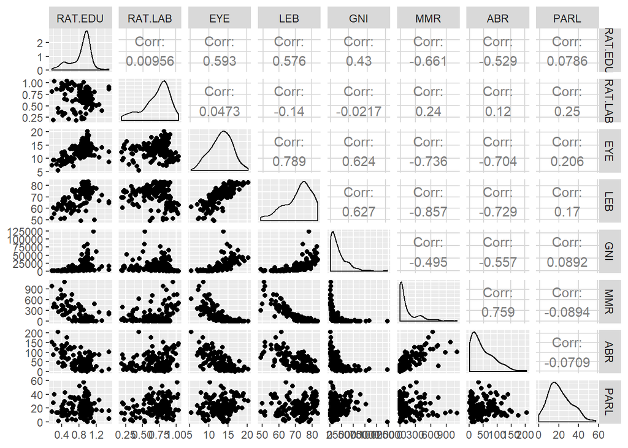

```r
# Access GGally and corrplot
library(GGally)
library(corrplot)
library(magrittr)
# visualize the 'human_' variables
ggpairs(human)
```

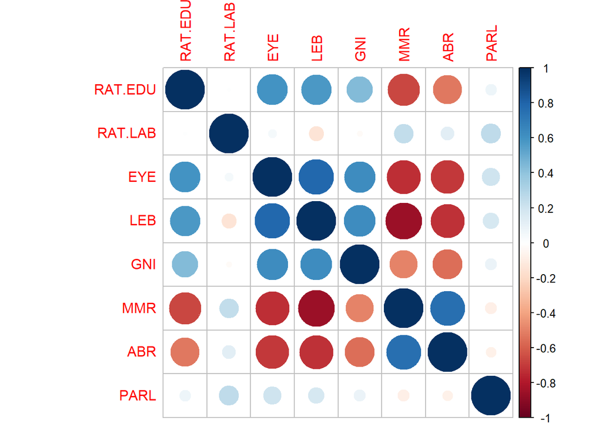

```r
# compute the correlation matrix and visualize it with corrplot
cor(human)%>%corrplot()
```

From a ggplot it is easier to see the distributions of the variables. Correlation plot helps to see the correlation between variables.

It seems that the higher the maternal mortality rates, MMR, (or adolescent birth rates, ABR), the lower the life expectancy, LEB,(or expected years of education, EYE). MMR and ABR, as well as LEB and EYE are correlated also.

## 2. Principal component analysis on unstandardized data

I perform principal component analysis on unscales human dataset.

```r
# perform principal component analysis (with the SVD method)
pca_human <- prcomp(human)

# create and print out a summary of pca_human
s <- summary(pca_human)
s
```

```
## Importance of components:
##                              PC1      PC2   PC3   PC4   PC5   PC6    PC7
## Standard deviation     1.854e+04 185.5219 25.19 11.45 3.766 1.566 0.1912
## Proportion of Variance 9.999e-01   0.0001  0.00  0.00 0.000 0.000 0.0000
## Cumulative Proportion  9.999e-01   1.0000  1.00  1.00 1.000 1.000 1.0000
##                           PC8
## Standard deviation     0.1591
## Proportion of Variance 0.0000
## Cumulative Proportion  1.0000
```

```r
# rounded percetanges of variance captured by each PC
pca_pr <- round(100*s$importance[2, ], digits = 1)

# print out the percentages of variance
pca_pr
```

```
## PC1 PC2 PC3 PC4 PC5 PC6 PC7 PC8
## 100   0   0   0   0   0   0   0
```

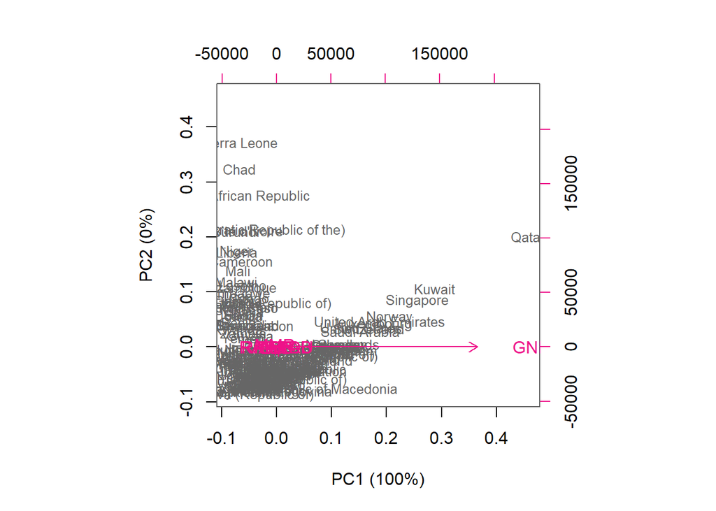

```r
# create object pc_lab to be used as axis labels
pc_lab<-paste0(names(pca_pr), " (", pca_pr, "%)")

# draw a biplot
biplot(pca_human, cex = c(0.8, 1), col = c("grey40", "deeppink2"), xlab = pc_lab[1], ylab = pc_lab[2])
```

From the summary table I can see that this kind of data is not suitable for the analysis. The first component supposedly is able to explain all the variation in the data set and the rest of the dimensions add nothing extra to the analysis.

From the biplot it is clear that variable GNI, gross national income, is the factor explaining everything. However, this is not case in reality. This result is just because GNI was the variable with the highest variation in the observations and therefore only “seems” to explain most of the variation. I should have standardized the data to make the variation of all the variables comparable.

## 3. PCA on standardized data

Usually variables have to be standardized for a PCA so I’ll do that and then rerun the analysis.

```r
human_std <- scale(human)

# perform principal component analysis (with the SVD method)
pca_human <- prcomp(human_std)

# create and print out a summary of pca_human
s <- summary(pca_human)
s
```

```
## Importance of components:
##                           PC1    PC2     PC3     PC4     PC5     PC6
## Standard deviation     2.0708 1.1397 0.87505 0.77886 0.66196 0.53631
## Proportion of Variance 0.5361 0.1624 0.09571 0.07583 0.05477 0.03595
## Cumulative Proportion  0.5361 0.6984 0.79413 0.86996 0.92473 0.96069
##                            PC7     PC8
## Standard deviation     0.45900 0.32224
## Proportion of Variance 0.02634 0.01298
## Cumulative Proportion  0.98702 1.00000
```

```r
# rounded percetanges of variance captured by each PC
pca_pr <- round(100*s$importance[2, ], digits = 1)

# print out the percentages of variance
pca_pr
```

```
##  PC1  PC2  PC3  PC4  PC5  PC6  PC7  PC8
## 53.6 16.2  9.6  7.6  5.5  3.6  2.6  1.3
```

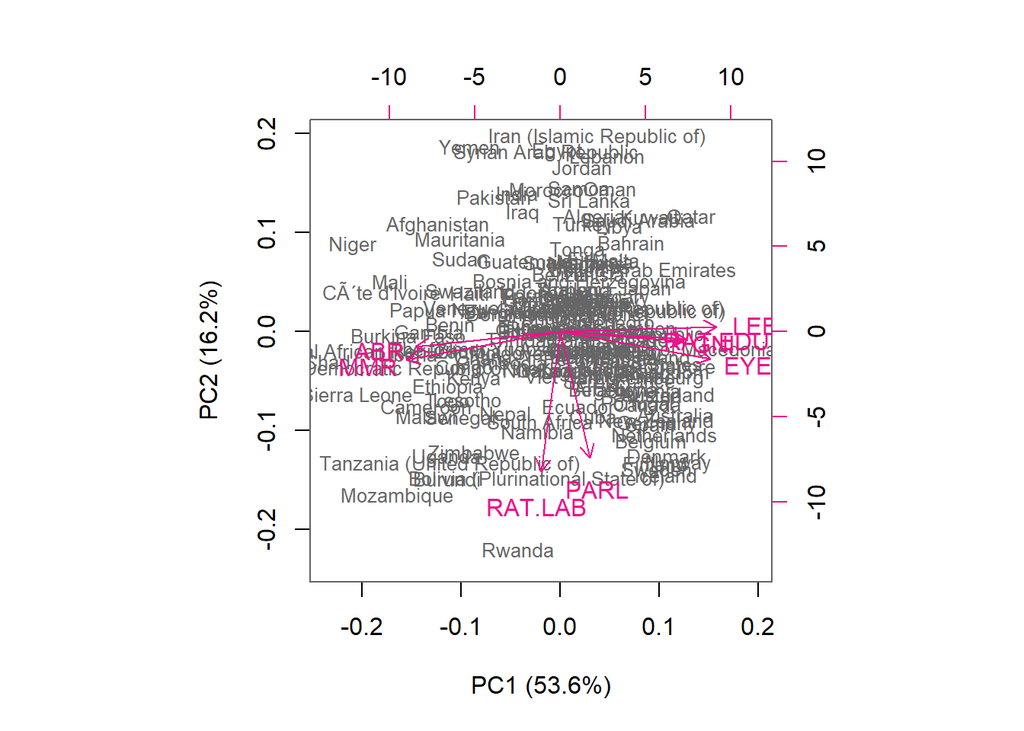

```r
# create object pc_lab to be used as axis labels
pc_lab<-paste0(names(pca_pr), " (", pca_pr, "%)")

# draw a biplot
biplot(pca_human, cex = c(0.8, 1), col = c("grey40", "deeppink2"), xlab = pc_lab[1], ylab = pc_lab[2])
```

Now the summary table shows more reasonable amounts of variation that each principal component (one after another) is able to explain. The first component explains 53.6 %.

Also the biplot makes more sense now. The first dimension doesn’t explain all the variation in the data and the second component supplements it. The variables are more apart in this biplot and no one variable is dominating. Gross national income is not the only factor explaining differences between the observations anymore. It is now only one factor amongst others. GNI is actually together with expected years of education, life expectancy at birth and ratio of females to males with at least secondary education. These variables tell of the same of thing and are correlated. In this biplot the variations of the variables are more equal and therefore each variable is able to explain its own bit of the observations.

## 4. Personal interpretation

The second biplot shows that variables GNI, LEB, RAT.EDU and EYE are positively correlated with principal component 1, whereas ABR and MMR are negatively correlated. Variables RAT.LAB and PARL are negatively correlated with principal component 2.

RAT.LAB, ratio of females to males in the labour force and PARL, percentage of female in the parliament, are variables that explain the second most largest part of the variation in the data. These two variables are somewhat correlated. Countries with high ratio of females at work have also high rate of females in parliament. These two variables are also orthogonal to other variables, meaning that they are not correlated with them. For example, a country with high GNI can have high or low rates of women in parliament.

## 5. Multiple Correspondence Analysis

If the variables are factors instead of numerical, we have to do a multiple correspondence analysis.

```r
library(dplyr)
library(tidyr)
library(FactoMineR)
data(tea)

# column names to keep in the dataset
keep_columns <- c("Tea", "How", "how", "sugar", "where", "lunch")

# select the 'keep_columns' to create a new dataset
tea_time <- select(tea, one_of(keep_columns))

# look at the summaries and structure of the data
summary(tea_time)
```

```
##         Tea         How                      how           sugar
##  black    : 74   alone:195   tea bag           :170   No.sugar:155
##  Earl Grey:193   lemon: 33   tea bag+unpackaged: 94   sugar   :145
##  green    : 33   milk : 63   unpackaged        : 36
##                  other:  9
##                   where           lunch
##  chain store         :192   lunch    : 44
##  chain store+tea shop: 78   Not.lunch:256
##  tea shop            : 30
##
```

```r
str(tea_time)
```

```
## 'data.frame':    300 obs. of  6 variables:
##  $ Tea  : Factor w/ 3 levels "black","Earl Grey",..: 1 1 2 2 2 2 2 1 2 1 ...
##  $ How  : Factor w/ 4 levels "alone","lemon",..: 1 3 1 1 1 1 1 3 3 1 ...
##  $ how  : Factor w/ 3 levels "tea bag","tea bag+unpackaged",..: 1 1 1 1 1 1 1 1 2 2 ...
##  $ sugar: Factor w/ 2 levels "No.sugar","sugar": 2 1 1 2 1 1 1 1 1 1 ...
##  $ where: Factor w/ 3 levels "chain store",..: 1 1 1 1 1 1 1 1 2 2 ...
##  $ lunch: Factor w/ 2 levels "lunch","Not.lunch": 2 2 2 2 2 2 2 2 2 2 ...
```

The tea dataset consists of 300 rows and 36 columns. Rows represent the individuals, columns represent the different questions. The first 18 questions are active ones, the 19th is a supplementary quantitative variable (the age) and the last variables are supplementary categorical variables. I didn’t find exact explanations for the variables but I chose 6 of them which are quite self-explanatory if you look at the variable names and observation values. All the variables are categorical.

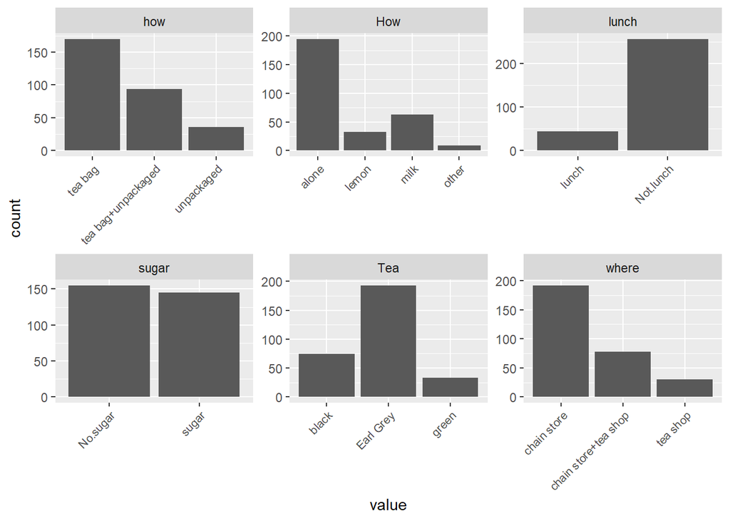

```r
# visualize the dataset
gather(tea_time) %>% ggplot(aes(value)) + facet_wrap("key", scales = "free") +geom_bar()+theme(axis.text.x = element_text(angle = 45, hjust = 1, size = 8))
```

Variables seem to have equal (sugar) or unequal (lunch) amounts of observations on each variable level.

I could guess that people who drink green tea drink it without sugar, alone and buy it unpackaged from a tea shop.

```r
# multiple correspondence analysis
mca <- MCA(tea_time, graph = FALSE)

# summary of the model
summary(mca)
```

```
##
## Call:
## MCA(X = tea_time, graph = FALSE)
##
##
## Eigenvalues
##                        Dim.1   Dim.2   Dim.3   Dim.4   Dim.5   Dim.6
## Variance               0.279   0.261   0.219   0.189   0.177   0.156
## % of var.             15.238  14.232  11.964  10.333   9.667   8.519
## Cumulative % of var.  15.238  29.471  41.435  51.768  61.434  69.953
##                        Dim.7   Dim.8   Dim.9  Dim.10  Dim.11
## Variance               0.144   0.141   0.117   0.087   0.062
## % of var.              7.841   7.705   6.392   4.724   3.385
## Cumulative % of var.  77.794  85.500  91.891  96.615 100.000
##
## Individuals (the 10 first)
##                       Dim.1    ctr   cos2    Dim.2    ctr   cos2    Dim.3
## 1                  | -0.298  0.106  0.086 | -0.328  0.137  0.105 | -0.327
## 2                  | -0.237  0.067  0.036 | -0.136  0.024  0.012 | -0.695
## 3                  | -0.369  0.162  0.231 | -0.300  0.115  0.153 | -0.202
## 4                  | -0.530  0.335  0.460 | -0.318  0.129  0.166 |  0.211
## 5                  | -0.369  0.162  0.231 | -0.300  0.115  0.153 | -0.202
## 6                  | -0.369  0.162  0.231 | -0.300  0.115  0.153 | -0.202
## 7                  | -0.369  0.162  0.231 | -0.300  0.115  0.153 | -0.202
## 8                  | -0.237  0.067  0.036 | -0.136  0.024  0.012 | -0.695
## 9                  |  0.143  0.024  0.012 |  0.871  0.969  0.435 | -0.067
## 10                 |  0.476  0.271  0.140 |  0.687  0.604  0.291 | -0.650
##                       ctr   cos2
## 1                   0.163  0.104 |
## 2                   0.735  0.314 |
## 3                   0.062  0.069 |
## 4                   0.068  0.073 |
## 5                   0.062  0.069 |
## 6                   0.062  0.069 |
## 7                   0.062  0.069 |
## 8                   0.735  0.314 |
## 9                   0.007  0.003 |
## 10                  0.643  0.261 |
##
## Categories (the 10 first)
```

[output cut: 16 more lines]

```
## lemon                0.035   3.226 |   1.329  14.771   0.218   8.081 |
## milk                 0.020   2.422 |   0.013   0.003   0.000   0.116 |
## other                0.102   5.534 |  -2.524  14.526   0.197  -7.676 |
## tea bag              0.161  -6.941 |  -0.065   0.183   0.006  -1.287 |
## tea bag+unpackaged   0.478  11.956 |   0.019   0.009   0.000   0.226 |
## unpackaged           0.141  -6.482 |   0.257   0.602   0.009   1.640 |
##
## Categorical variables (eta2)
##                      Dim.1 Dim.2 Dim.3
## Tea                | 0.126 0.108 0.410 |
## How                | 0.076 0.190 0.394 |
## how                | 0.708 0.522 0.010 |
## sugar              | 0.065 0.001 0.336 |
## where              | 0.702 0.681 0.055 |
## lunch              | 0.000 0.064 0.111 |
```

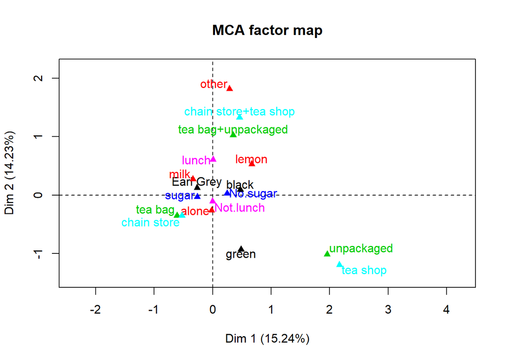

```r
# visualize MCA
plot(mca, invisible=c("ind"),habillage = "quali")
```

From the summary and from the biplot it seems that the dimensions are not able to explain much of the variation. The first dimension explains “only” 15 % of the variation.

There are some factor levels that are similar (close to each other in the biplot). For example, people who drink ‘unpackaged’ tea buy tea from ‘tea shops’. Makes sense. And on the opposite, people who consume ‘tea bags’ buy tea from ‘chain stores’. My assumption of people drinking unpackaged green tea bought from tea shops is not far fetched because ‘green’ is also rather similar (close to) with ‘unpackaged’ and ‘tea shop’. ‘No sugar’ and ‘alone’ are farther off but still closer than ‘sugar’ or ‘lemon’, ‘milk’ or ‘other’.